# DO Data Patterns

# Purpose

To identify the patterns used in the Human Disease Ontology and to explore somewhat how they have changed over time. *For information regarding definitions or data types, see the corresponding R notebooks.*

```r
r <- DO.utils::DOrepo("~/Documents/Ontologies/HumanDiseaseOntology")
```

# Synonym Patterns

```r
q <- '# Return a list of all non-obsolete synonyms with metadata

PREFIX rdfs: <http://www.w3.org/2000/01/rdf-schema#>
PREFIX owl: <http://www.w3.org/2002/07/owl#>
PREFIX oboInOwl: <http://www.geneontology.org/formats/oboInOwl#>

SELECT ?id ?label ?syn_type ?synonym
WHERE {
    ?class a owl:Class ;
        ?pred ?synonym .
    FILTER(CONTAINS(STR(?class), "DOID"))
    FILTER(REGEX(STR(?pred), "[Ss]ynonym"))

    OPTIONAL { ?class oboInOwl:id ?id . }
    OPTIONAL { ?class rdfs:label ?label . }

    BIND(STRAFTER(STR(?pred), "oboInOwl#") AS ?syn_type)
    FILTER NOT EXISTS { ?class owl:deprecated ?obsolete . }
}'

syn <- r$doid$query(q) %>%
    tibble::as_tibble()
```

```r
q <- '# Return a list of all non-obsolete cross-references with metadata

PREFIX rdfs: <http://www.w3.org/2000/01/rdf-schema#>
PREFIX owl: <http://www.w3.org/2002/07/owl#>
PREFIX oboInOwl: <http://www.geneontology.org/formats/oboInOwl#>

SELECT ?id ?label ?xref
WHERE {
    ?class a owl:Class ;
        oboInOwl:hasDbXref ?xref .
    FILTER(CONTAINS(STR(?class), "DOID"))

    OPTIONAL { ?class oboInOwl:id ?id . }
    OPTIONAL { ?class rdfs:label ?label . }

    FILTER NOT EXISTS { ?class owl:deprecated ?obsolete . }
}'

xref <- r$doid$query(q) %>%
    tibble::as_tibble()
```

## OMIM

```r
omim_syn <- syn %>%
    dplyr::filter(
        id %in% dplyr::filter(xref, stringr::str_detect(xref, "OMIM"))$id
    )
```

1. How many synonyms for diseases with OMIM xrefs use direct OMIM patterns?

Omim patterns may include:

- fully upper-case, may have commas and/or end with a number
- upper-case abbreviations

```r
is_letter <- function(x) {
    x %in% c(letters, LETTERS)
}

has_num <- function(x) {
    stringr::str_detect(x, "[0-9]")
}

is_roman_numeral <- function(x, .max = 100) {
    x %in% as.character(as.roman(1:.max))
}

is_short <- function(x, n_short = 4) {
    stringr::str_length(x) <= n_short
}

ignore <- function(x) {
    is_letter(x) | has_num(x) | is_roman_numeral(x) | is_short(x)
}

has_space <- function(x) {
    stringr::str_detect(x, " ")
}

has_dict_word <- function(x) {
    tokens <- stringr::str_split(x, " ")
    token_df <- tibble::tibble(
        idx = vctrs::vec_rep_each(seq_along(tokens), lengths(tokens)),
        token = purrr::flatten_chr(tokens),
        ignore = ignore(token),
        is_word = hunspell::hunspell_check(token),
        has_word = is_word & !ignore
    )

    token_df %>%
        dplyr::group_by(idx) %>%
        dplyr::summarize(has_word = any(has_word)) %>%
        .$has_word
}

is_abbreviation <- function(x) {
    stringr::str_detect(x,"^[A-Z0-9]{1,8}[ +/\\-]?([A-Z0-9]{1,8})?$") &
        !(has_dict_word(x) & has_space(x))
}
```

```r
omim_syn <- omim_syn %>%
    dplyr::mutate(
        synonym = stringr::str_squish(synonym),
        comma = stringr::str_count(synonym, ","),
        abbrev = is_abbreviation(synonym),
        uppercase = stringr::str_detect(synonym, "[A-Z]+") &
            !stringr::str_detect(synonym, "[a-z]+")
    )

dplyr::count(omim_syn, uppercase, abbrev)
```

| uppercase | abbrev | n |
| --- | --- | --- |
| FALSE | FALSE | 7351 |
| TRUE | FALSE | 103 |
| TRUE | TRUE | 3386 |

Very few synonyms are uppercase that are not abbreviations. I guess that should be avoided.

What about arranging things with commas?

```r
dplyr::count(omim_syn, comma) %>%
    dplyr::mutate(pct = round(n / sum(n) * 100, 1))
```

| comma | n | pct |
| --- | --- | --- |
| 0 | 10142 | 93.6 |
| 1 | 439 | 4.0 |
| 2 | 190 | 1.8 |
| 3 | 52 | 0.5 |
| 4 | 9 | 0.1 |
| 5 | 5 | 0.0 |
| 6 | 3 | 0.0 |

Commas are VERY uncommon in synonyms for diseases with OMIM xrefs and where they are found they are generally limited in quantity. Looking more closely at individual records, multiple commas first…

```r
dplyr::filter(omim_syn, comma > 0) %>%
    dplyr::select(synonym, comma, id) %>%
    dplyr::arrange(dplyr::desc(comma))
```

| synonym | comma | id |
| --- | --- | --- |
| diaphragmatic hernia, exomphalos, absent corpus callosum, hypertelorism, myopia, sensorineural deafness, and proteinuria | 6 | DOID:0090144 |
| SCID, T-cell negative, B-cell positive, NK cell positive, with intellectual disability, spasticity, and craniofacial abnormalities | 6 | DOID:0111979 |
| severe combined immunodeficiency, T-cell negative, B-cell positive, NK cell positive, with intellectual disability, spasticity, and craniofacial abnormalities | 6 | DOID:0111979 |
| mental retardation, enteropathy, deafness, neuropathy, ichthyosis, keratodermia | 5 | DOID:0060483 |
| short stature, hyperextensibility, hernia, ocular depression, Rieger anomaly, and teething delay | 5 | DOID:0111454 |
| growth retardation, amino aciduria, cholestasis, iron overload, lactic acidosis, and early death | 5 | DOID:0111455 |
| cataracts, congenital, with sensorineural deafness, Down syndrome-like facial appearance, short stature, and mental retardation | 5 | DOID:0111688 |
| hypogonadism, alopecia, diabetes mellitus, mental retardation, deafness, and extrapyramidal syndrome | 5 | DOID:0112264 |
| ADRENAL INSUFFICIENCY, CONGENITAL, WITH 46,XY SEX REVERSAL, PARTIAL OR COMPLETE | 4 | DOID:0050546 |
| mental retardation, epileptic seizures, hypogonadism and hypogenitalism, microcephaly, and obesity | 4 | DOID:0060801 |

[output cut: 688 more lines]

How has the inclusion of commas changed over time?

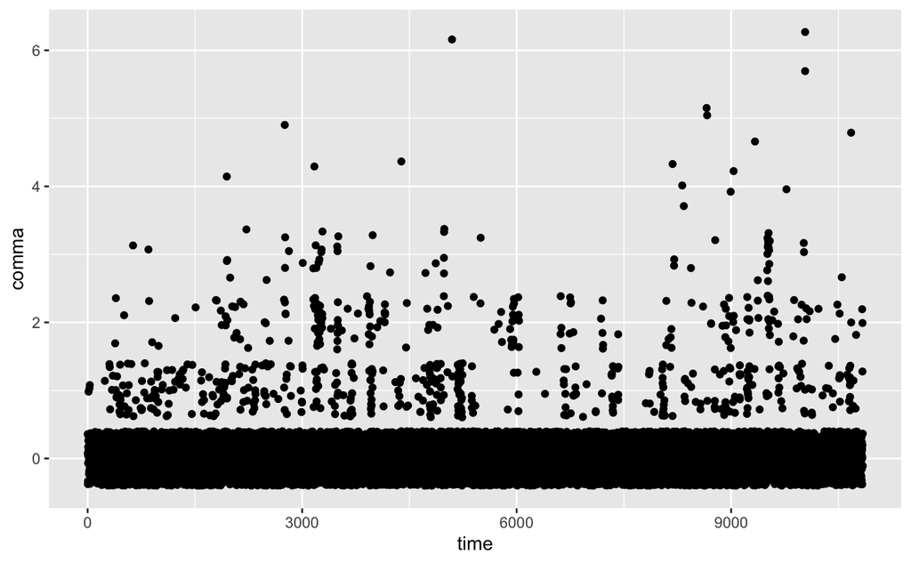

```r
omim_w_time <- omim_syn %>%
    dplyr::mutate(
        time = dplyr::row_number(
            as.integer(stringr::str_remove(id, ".*:"))
        )
    )

ggplot(omim_w_time, aes(x = time, y = comma)) +
    geom_jitter()
```

Including the synonyms without commas really emphasizes that most don’t have them but makes it hard to see if changes have occurred.

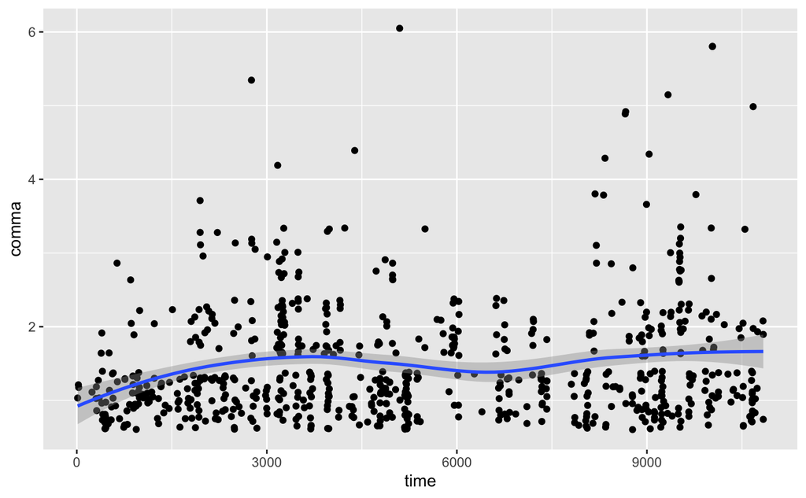

```r
omim_w_time %>%
    dplyr::filter(comma > 0) %>%
    ggplot(aes(x = time, y = comma)) +
    geom_jitter() +
    geom_smooth(method = "loess", formula = "y ~ x")
```

It doesn’t look like there’s much change. It must be that synonyms with commas are generally NOT added but added as needed.

# Disease Classification

How are diseases classified relative to other medical terminologies?

## OMIM

**Questions:**

1. How does DO respond when OMIM splits a disease with a specific gene (subtype) with differences in inheritance (sub-subtype)?

The examples here go beyond differences in inheritance. Some of these may need to be revised, particularly where two diseases have the same definition.

```r
do_def <- r$doid$query(
    "SELECT ?id ?label ?def ?parent ?omim
    WHERE {
        ?class oboInOwl:id ?id ;
            rdfs:label ?label ;
            obo:IAO_0000115 ?def ;
            rdfs:subClassOf ?superclass .
        ?superclass rdfs:label ?parent .
        FILTER NOT EXISTS { ?class owl:deprecated ?any . }
        OPTIONAL {
            ?class oboInOwl:hasDbXref ?omim .
            FILTER(CONTAINS(str(?omim), 'OMIM'))
        }
    }"
) %>%
    DO.utils::tidy_sparql() %>%
    DO.utils::collapse_col(c(parent, omim), na.rm = TRUE)
```

```r
omim_sub2 <- do_def %>%
    dplyr::mutate(
        gene = stringr::str_match(def, "([A-Z0-9]{3,}) gene[ .]")[,2],
        label_base = stringr::str_remove(label, " [0-9]+[A-Z]+$")
    ) %>%
    dplyr::filter(stringr::str_detect(label, "[0-9]+[A-Z]+$")) %>%
    dplyr::group_by(label_base) %>%
    dplyr::filter(
        DO.utils::all_duplicated(gene),
        !is.na(gene)
    ) %>%
    dplyr::ungroup() %>%
    dplyr::arrange(label_base, gene)
```

In no case for groups of diseases where the labels differ only by an alphanumeric identifier and they are caused by mutations in the same gene has a parent grouping disease been created. This suggests strongly avoiding the creation of such low-level grouping disease terms.

# Disease Naming

## OMIM

### Roman Numerals

**Are OMIM diseases with roman numeral types converted to integer numbers in disease names or retained as is?**

```r
# DO diseases with "type" in the name and OMIM xrefs
omim_DOtype <- xref %>%
    dplyr::filter(
        stringr::str_detect(xref, 'OMIM'),
        stringr::str_detect(
            label,
            stringr::regex(" [a-z]{0,1}[ixv0-9]+[a-z]{0,2}$", ignore_case = TRUE)
        )
    ) %>%
    dplyr::rename(omim = xref) %>%
    dplyr::mutate(
        roman_n = stringr::str_detect(
            label,
            stringr::regex(" [a-z]{0,1}[ixv]+[a-z]{0,2}$", ignore_case = TRUE)
        )
    )
```

Looking just as DO names with numerals it is clear that integers are preferred over roman numerals.

```r
dplyr::count(omim_DOtype, roman_n) %>%
    dplyr::mutate(pct = round(n / sum(n) * 100, 1))
```

| roman_n | n | pct |
| --- | --- | --- |
| FALSE | 2962 | 95.2 |
| TRUE | 148 | 4.8 |

```r
dplyr::filter(omim_DOtype, roman_n)
```

| id | label | omim | roman_n |
| --- | --- | --- | --- |
| DOID:0050570 | congenital disorder of glycosylation type I | OMIM:PS212065 | TRUE |
| DOID:0050571 | congenital disorder of glycosylation type II | OMIM:PS212066 | TRUE |
| DOID:0050579 | glycogen storage disease XV | OMIM:613507 | TRUE |
| DOID:0050725 | tyrosinemia type II | OMIM:276600 | TRUE |
| DOID:0050726 | tyrosinemia type I | OMIM:276700 | TRUE |
| DOID:0050727 | tyrosinemia type III | OMIM:276710 | TRUE |
| DOID:0050809 | mucopolysaccharidosis IX | OMIM:601492 | TRUE |
| DOID:0060316 | orofaciodigital syndrome I | OMIM:311200 | TRUE |
| DOID:0060362 | punctate palmoplantar keratoderma type III | OMIM:101850 | TRUE |
| DOID:0060373 | orofaciodigital syndrome III | OMIM:258850 | TRUE |

[output cut: 138 more lines]

```r
####### data from 'OMIM updates from MGI' sheet #######
raw_omim <- googlesheets4::read_sheet(
    ss = "1SUiFOMGeO3QJfnevpXAPFN90UmAaeoIHF7u0X5lvgc4",
    sheet = "OMIM Term changes"
)

# tidy-ish data
tbl_pos <- which(raw_omim$...1 == "OMIM ID")
omim_tidy <- raw_omim %>%
    dplyr::filter(
        dplyr::row_number() > tbl_pos,
        !dplyr::if_all(.cols = dplyr::everything(), .fns = is.na)
    )
blank_col <- paste0(
    rep("...", length(names(omim_tidy)) - 4),
    1:(length(names(omim_tidy)) - 4)
)
names(omim_tidy) <- c("omim", "old", "new", "DOID", blank_col)
omim_tidy <- omim_tidy %>%
    dplyr::select(-tidyselect::starts_with("..."))

# newer statements needing parsing
omim_stmt <- raw_omim$...1[1:(tbl_pos - 1)] %>%
    na.omit()
omim_rename <- omim_stmt[stringr::str_detect(omim_stmt, "was.*(now|changed to)")] %>%
    stringr::str_match(
        stringr::regex(
            "(?<omim>OMIM[: ]P?S?[0-9]+)(?: *was) (?<old>.+) *(?:(?:this )?(?:(?:is)? now|changed to) *(?<new>.+))(?: *not| *xref| *made| *map| *name| *this| *\\(| *-|$)",
            ignore_case = TRUE
        )
    ) %>%
    tibble::as_tibble(.name_repair = "universal") %>%
    dplyr::mutate(
        old = stringr::str_remove(old, " *is *$"),
        new = stringr::str_remove(
            new,
            " (not|xref|made|map|name|this|\\(|-).*"
        )
    )
omim_dep <- omim_stmt[stringr::str_detect(omim_stmt, "OBSOLETE|obsolete")] %>%
    stringr::str_match("(?<omim>OMIM[: ]P?S?[0-9]+) (?:was )?(?<old>.+) (?:made|- )") %>%
    tibble::as_tibble(.name_repair = "universal") %>%
    dplyr::filter(!dplyr::if_all(.cols = dplyr::everything(), .fns = is.na)) %>%
    tibble::add_column(deprecated = TRUE)
omim_nm <- omim_stmt[!stringr::str_detect(omim_stmt, "was.*(now|changed to)|OBSOLETE|obsolete")] %>%
    stringr::str_match("(?<omim>OMIM[: ]P?S?[0-9]+) (?<old>[A-Z][^\\(]+)") %>%
    tibble::as_tibble(.name_repair = "universal") %>%
    dplyr::mutate(old = stringr::str_trim(old)) %>%
    dplyr::filter(!dplyr::if_all(.cols = dplyr::everything(), .fns = is.na))

omim_tidy2 <- dplyr::bind_rows(omim_nm, omim_dep, omim_rename) %>%
    dplyr::select(-tidyselect::starts_with("..."))

omim_tidy <- dplyr::bind_rows(omim_tidy, omim_tidy2) %>%
    dplyr::mutate(
        # drop acronyms, etc.
        old = stringr::str_remove(old, ";.*"),
        new = stringr::str_remove(new, ";.*"),
        # identify OMIM with numerals
        has_integer = stringr::str_detect(
            old,
            stringr::regex(" [a-z]{0,1}[0-9]+[a-z]{0,2}$", ignore_case = TRUE)
        ) |
            stringr::str_detect(
            new,
            stringr::regex(" [a-z]{0,1}[0-9]+[a-z]{0,2}$", ignore_case = TRUE)
        ),
        old_roman = stringr::str_detect(
            old,
            stringr::regex(" [a-z]{0,1}[ixv]+[a-z]{0,2}$", ignore_case = TRUE)
        ),
        new_roman = stringr::str_detect(
            new,
            stringr::regex(" [a-z]{0,1}[ixv]+[a-z]{0,2}$", ignore_case = TRUE)
        )
    )
```

Filtering out the OMIM names I have that do not contain a numeral, it would seem I only have a very small dataset of OMIM names with integer or roman numerals to work with.

```r
omim_tidy %>%
    dplyr::filter(has_integer | old_roman | new_roman) %>%
    dplyr::count(old_roman, new_roman)
```

| old_roman | new_roman | n |
| --- | --- | --- |
| FALSE | FALSE | 651 |
| FALSE | TRUE | 1 |
| FALSE | NA | 8 |
| TRUE | FALSE | 25 |
| TRUE | TRUE | 19 |
| TRUE | NA | 3 |

On intial inspection it seems that OMIM strongly prefers integers to roman numerals (expected), and it appears they convert roman numerals to integers to a much greater extent than the opposite. The sample size is small so I’m hesitant to make any real conclusions.

Just looking at OMIM names with roman numerals it’s clear that the observations above, while true, are not the entire story because more complex renames occur and OMIM names themselves may be reordered with commas.

```r
omim_tidy %>%
    dplyr::filter(old_roman | new_roman)
```

| omim | old | new | DOID | deprecated | has_integer | old_roman | new_roman |
| --- | --- | --- | --- | --- | --- | --- | --- |
| OMIM:250790 | Methemoglobinemia Type IV | Methemoglobinemia and Ambiguous Genitalia | not in DO | NA | FALSE | TRUE | FALSE |
| OMIM:253200 | Mucopolysaccharidosis Type VI | Mucopolysaccharidosis, Type VI | DOID:12800, new synonym | NA | FALSE | TRUE | TRUE |
| OMIM:612937 | Congenital Disorder of Glycosylation, Type Io | Muscular Dystrophy-Dystroglycanopathy (limb-Girdle), Type C, 15 | DOID:0050570 - unsplit series | NA | TRUE | TRUE | FALSE |
| OMIM:307200 | Isolated Growth Hormone Deficiency, Type III | Isolated Growth Hormone Deficiency, Type III, with Agammaglobulinemia | DOID:0060875 | NA | FALSE | TRUE | FALSE |
| OMIM:613480 | Lymphedema, Hereditary, Ic | Lymphatic Malformation 3 | NA | NA | TRUE | TRUE | FALSE |
| OMIM:153200 | Lymphedema, Hereditary, II | Lymphatic Malformation 5 | NA | NA | TRUE | TRUE | FALSE |
| OMIM:611944 | Lymphedema, Hereditary, IB | Lymphatic Malformation 2 | NA | NA | TRUE | TRUE | FALSE |
| OMIM:615907 | Lymphedema, Hereditary, ID | Lymphatic Malformation 4 | NA | NA | TRUE | TRUE | FALSE |
| OMIM:616843 | Lymphedema, Hereditary, III | Lymphatic Malformation 6 | NA | NA | TRUE | TRUE | FALSE |
| OMIM:153100 | Lymphedema, Hereditary, IA | Lymphatic Malformation 1 | NA | NA | TRUE | TRUE | FALSE |

[output cut: 38 more lines]

This is the comparison of OMIM names to DO names.

```r
omim_nm_compare <- dplyr::left_join(omim_DOtype, omim_tidy, by = "omim") %>%
    dplyr::select(-DOID, -deprecated) %>%
    dplyr::rename(DO_roman = roman_n, omim_integer = has_integer) %>%
    dplyr::filter(omim_integer | old_roman | new_roman)
```

Most diseases in DO and OMIM do not have roman numerals, period. That makes the roman numeral dataset too small to really draw any conclusions from.

```r
omim_nm_compare %>%
    dplyr::count(DO_roman, old_roman, new_roman) %>%
    dplyr::mutate(pct = round(n / sum(n) * 100, 1))
```

| DO_roman | old_roman | new_roman | n | pct |
| --- | --- | --- | --- | --- |
| FALSE | FALSE | FALSE | 398 | 91.5 |
| FALSE | FALSE | NA | 5 | 1.1 |
| FALSE | TRUE | FALSE | 7 | 1.6 |
| FALSE | TRUE | TRUE | 6 | 1.4 |
| TRUE | FALSE | FALSE | 1 | 0.2 |
| TRUE | TRUE | FALSE | 9 | 2.1 |
| TRUE | TRUE | TRUE | 6 | 1.4 |
| TRUE | TRUE | NA | 3 | 0.7 |

Here’s the full set of diseases with roman numeral anywhere (OMIM or DO), for viewing purposes.

```r
omim_nm_compare %>%
    dplyr::filter(DO_roman | old_roman | new_roman)
```

| id | label | omim | DO_roman | old | new | omim_integer | old_roman | new_roman |
| --- | --- | --- | --- | --- | --- | --- | --- | --- |
| DOID:0060875 | isolated growth hormone deficiency type III | OMIM:307200 | TRUE | Isolated Growth Hormone Deficiency, Type III | Isolated Growth Hormone Deficiency, Type III, with Agammaglobulinemia | FALSE | TRUE | FALSE |
| DOID:0070129 | autosomal recessive cutis laxa type IID | OMIM:617403 | TRUE | Cutis Laxa, Autosomal Recessive, Type Iid | NA | NA | TRUE | NA |
| DOID:0070140 | autosomal recessive cutis laxa type IIC | OMIM:617402 | TRUE | Cutis Laxa, Autosomal Recessive, Type IIC | NA | NA | TRUE | NA |
| DOID:0070191 | autosomal recessive chronic granulomatous disease 2 | OMIM:233710 | FALSE | Granulomatous Disease, Chronic, Autosomal Recessive, Cytochrome B-Positive, Type II | Granulomatous Disease, Chronic, Autosomal Recessive, 2 | TRUE | TRUE | FALSE |
| DOID:0070192 | autosomal recessive chronic granulomatous disease 1 | OMIM:233700 | FALSE | Granulomatous Disease, Chronic, Autosomal Recessive, Cytochrome B-Positive, Type I | Granulomatous Disease, Chronic, Autosomal Recessive, 1 | TRUE | TRUE | FALSE |
| DOID:0070194 | autosomal recessive chronic granulomatous disease 3 | OMIM:613960 | FALSE | Granulomatous Disease, Chronic, Autosomal Recessive, Cytochrome B-Positive, Type III | Granulomatous Disease, Chronic, Autosomal Recessive, 3 | TRUE | TRUE | FALSE |
| DOID:0070208 | hereditary lymphedema IC | OMIM:613480 | TRUE | Lymphedema, Hereditary, Ic | Lymphatic Malformation 3 | TRUE | TRUE | FALSE |
| DOID:0070209 | hereditary lymphedema ID | OMIM:615907 | TRUE | Lymphedema, Hereditary, ID | Lymphatic Malformation 4 | TRUE | TRUE | FALSE |
| DOID:0070210 | hereditary lymphedema IA | OMIM:153100 | TRUE | Lymphedema, Hereditary, IA | Lymphatic Malformation 1 | TRUE | TRUE | FALSE |
| DOID:0070211 | hereditary lymphedema IB | OMIM:611944 | TRUE | Lymphedema, Hereditary, IB | Lymphatic Malformation 2 | TRUE | TRUE | FALSE |

[output cut: 22 more lines]

#### Conclusion

Since it is not possible to determine empirically how to handle OMIM phenotypes with roman numerals I will retain them as is for the time being (2023-07-17).